# Data Structures

27 May 2015

## Welcome to R for Biochemists

- Aim: show how to use R to analyse biochemical data.
- Step 2: exploring data structures
- Example: a protein assay
- [R for Biochemists Blog](http://rforbiochemists.blogspot.co.uk/)
- http://medicine.cf.ac.uk/person/paul-brennan/

## Data goes into objects

```r
# Use the assignment function "<-"
# Protein Concentrations
prot <- c(0.000, 0.016, 0.031, 0.063, 0.125, 0.250, 0.500, 1.000,
          0.000, 0.016, 0.031, 0.063, 0.125, 0.250, 0.500, 1.000)

# Absorbance from my protein assay
abs <- c(0.329, 0.352, 0.349, 0.379, 0.417, 0.491, 0.668, 0.956,
         0.327, 0.341, 0.355, 0.383, 0.417, 0.446, 0.655, 0.905)
```

## These objects are vectors

### They appear in the R-Studio environment as Values

```r
str(prot)
```

num [1:16] 0 0.016 0.031 0.063 0.125 0.25 0.5 1 0 0.016 …

```r
str(abs)
```

num [1:16] 0.329 0.352 0.349 0.379 0.417 0.491 0.668 0.956 0.327 0.341 …

## These objects are vectors

- A vector is the simplist type of object
- All the data elements must be the same type
- Can be numeric, character, logical, factors

```r
class(prot)
```

```
## [1] "numeric"
```

## Other classes of variables

```r
protein <- "albumin"
class(protein)
```

[1] "character"

```r
truth <- c(TRUE, FALSE, TRUE, TRUE)
class(truth)
```

[1] "logical"

## To output vectors

### write the name of the vector

```r
prot
```

```
##  [1] 0.000 0.016 0.031 0.063 0.125 0.250 0.500 1.000 0.000 0.016 0.031
## [12] 0.063 0.125 0.250 0.500 1.000
```

## To identify elements inside the vector

```r
prot[2]  # second element of the vector
```

[1] 0.016

```r
### or parts of objects
prot[1:8]  # elements 1 to 8 of the vector
```

[1] 0.000 0.016 0.031 0.063 0.125 0.250 0.500 1.000

## Functions can be applied to whole objects

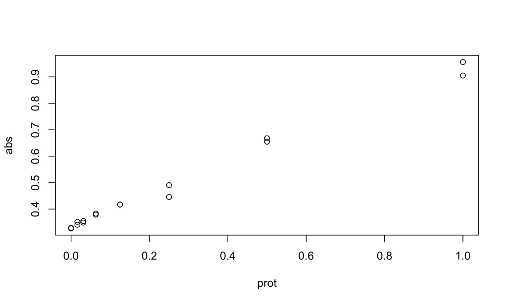

```r
#plot() function uses the elements in order
plot(abs~prot)
```

## More Complicated Structures

## Lists are another type of object

- The lm() function makes an object called "line"
- "line" is a list.
- Lists can contain mixture of data classes.

```r
line <- lm(abs~prot)
### not the assignment function "<-"
### the R-Studio environment says a "List of 12"
```

## Extracting information from lists

### There are various ways

```r
## type the name of the object
line
```

```
##
## Call:
## lm(formula = abs ~ prot)
##
## Coefficients:
## (Intercept)         prot
##       0.336        0.603
```

## Extracting information from lists

```r
summary(line)   ## use the summary() function
```

```
##
## Call:
## lm(formula = abs ~ prot)
##
## Residuals:
##       Min        1Q    Median        3Q       Max
## -0.040756 -0.006025  0.004625  0.007011  0.030494
##
## Coefficients:
##             Estimate Std. Error t value Pr(>|t|)
## (Intercept) 0.336005   0.005801   57.92  < 2e-16 ***
## prot        0.603002   0.014211   42.43 3.42e-16 ***
## ---
## Signif. codes:  0 '***' 0.001 '**' 0.01 '*' 0.05 '.' 0.1 ' ' 1
##
## Residual standard error: 0.01843 on 14 degrees of freedom
## Multiple R-squared:  0.9923, Adjusted R-squared:  0.9917
## F-statistic:  1801 on 1 and 14 DF,  p-value: 3.421e-16
```

## Extracting information from lists

```r
## use the $  - VERY USEFUL
summary(line)$r.squared
```

[1] 0.9922846

## We used $ to extract the r2 for the graph

### We created the object r2 using the function summary()

```r
r2 <- summary(line)$r.squared
### and the function round() - gives us three decimal points
r2 <- round(summary(line)$r.squared, 3)
r2
```

[1] 0.992

```r
class(r2)
```

[1] "numeric"

```r
### from the list we have extracted a number.
```

## Matrices are two dimensional structures

### Data classes are all the same

## Data frames are two dimensional structures

### Contains different classes of data

## When we import data, it often becomes a data frame.

- here is an example:

```r
data <- read.csv("http://science2therapy.com/data/wellsDataSimp.csv")
```

### the R-Studio environment puts it in "data" and gives us some info

## Have a look at it

```r
data
```

```
##    Section  FBS Virus Host.cell      HA   P.Erk S.phase.cnt
## 1    A - 1 None   Ctl  PPase WT  27.660  47.338          49
## 2    A - 2 None   Ctl  PPase KO  29.338  30.484          15
## 3    A - 3 None   Q61  PPase WT 168.447 113.604          79
## 4    A - 4 None   Q61  PPase KO  60.078  72.518          23
## 5    A - 5 None V600F  PPase WT 493.870 277.264          37
## 6    A - 6 None V600F  PPase KO 331.101 316.447          25
## 7    A - 7 None   Ctl  PPase WT  32.868  31.112          41
## 8    A - 8 None   Ctl  PPase KO  29.873  27.757          15
## 9    A - 9 None   Q61  PPase WT 131.936 118.016         102
## 10  A - 10 None   Q61  PPase KO  53.367  50.155          14
## 11  A - 11 None V600F  PPase WT 455.678 262.686          31
## 12  A - 12 None V600F  PPase KO 406.016 262.235          15
## 13   B - 1 None   Ctl  PPase WT  28.336  27.649          42
## 14   B - 2 None   Ctl  PPase KO  30.019  28.993          22
```

[output cut: 82 more lines]

## Look at the structure

- Names of columns
- Class of the data within the column

```r
str(data)
```

```
## 'data.frame':    96 obs. of  7 variables:
##  $ Section    : Factor w/ 96 levels "A - 1","A - 10",..: 1 5 6 7 8 9 10 11 12 2 ...
##  $ FBS        : Factor w/ 2 levels "10%","None": 2 2 2 2 2 2 2 2 2 2 ...
##  $ Virus      : Factor w/ 3 levels "Ctl","Q61","V600F": 1 1 2 2 3 3 1 1 2 2 ...
##  $ Host.cell  : Factor w/ 2 levels "PPase KO","PPase WT": 2 1 2 1 2 1 2 1 2 1 ...
##  $ HA         : num  27.7 29.3 168.4 60.1 493.9 ...
##  $ P.Erk      : num  47.3 30.5 113.6 72.5 277.3 ...
##  $ S.phase.cnt: int  49 15 79 23 37 25 41 15 102 14 ...
```

### note: Factors, num, int

## Extracting information from data frames

- use $ and the column name

```r
data$Virus
```

```
##  [1] Ctl   Ctl   Q61   Q61   V600F V600F Ctl   Ctl   Q61   Q61   V600F
## [12] V600F Ctl   Ctl   Q61   Q61   V600F V600F Ctl   Ctl   Q61   Q61
## [23] V600F V600F Ctl   Ctl   Q61   Q61   V600F V600F Ctl   Ctl   Q61
## [34] Q61   V600F V600F Ctl   Ctl   Q61   Q61   V600F V600F Ctl   Ctl
## [45] Q61   Q61   V600F V600F Ctl   Ctl   Q61   Q61   V600F V600F Ctl
## [56] Ctl   Q61   Q61   V600F V600F Ctl   Ctl   Q61   Q61   V600F V600F
## [67] Ctl   Ctl   Q61   Q61   V600F V600F Ctl   Ctl   Q61   Q61   V600F
## [78] V600F Ctl   Ctl   Q61   Q61   V600F V600F Ctl   Ctl   Q61   Q61
## [89] V600F V600F Ctl   Ctl   Q61   Q61   V600F V600F
## Levels: Ctl Q61 V600F
```

## Simple plot from this data frame

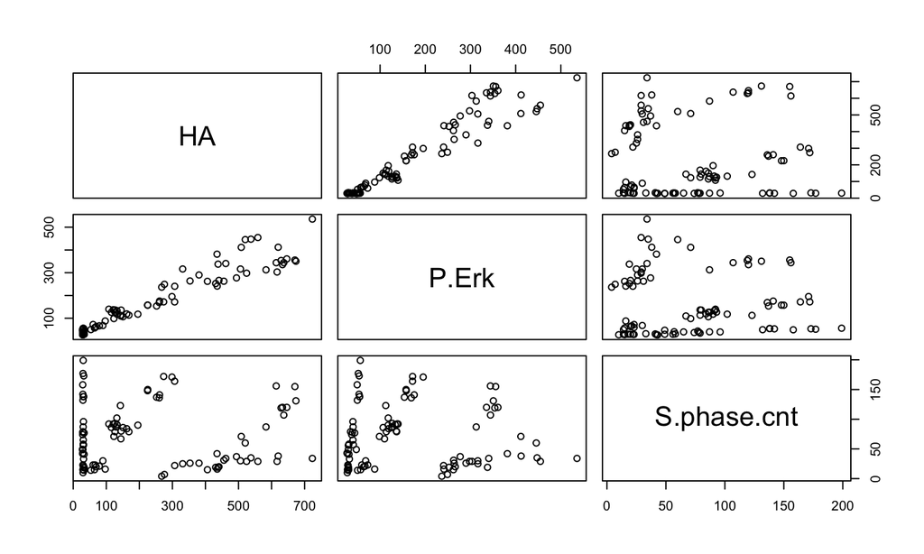

```r
plot(data[5:7])  # these are the column numbers
```

## Another plot from this data frame

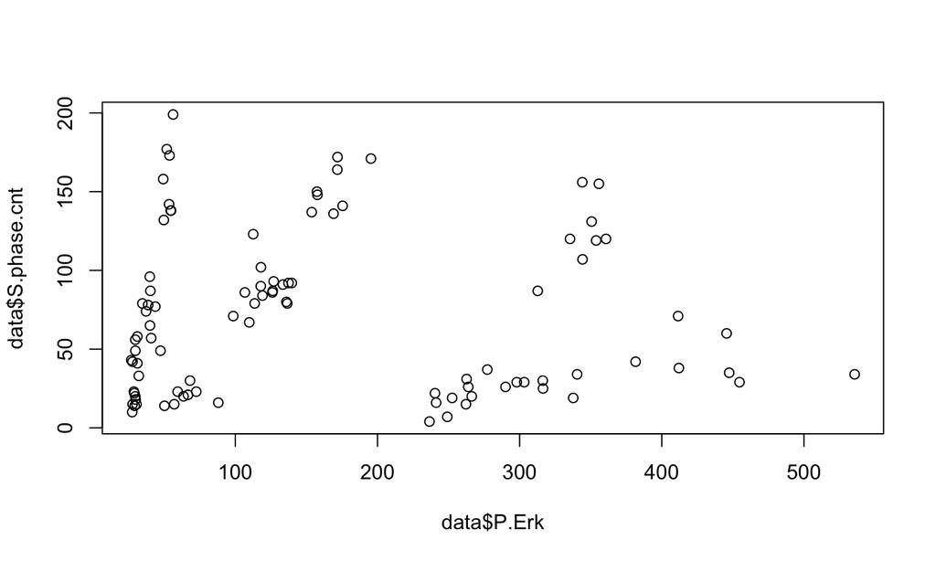

```r
plot(data$P.Erk, data$S.phase.cnt)
```

## Summary

- Vectors - simple object, data same class
- Lists - one dimensional object, data different class
- Extract data out of List - summary(line)$r.squared
- Data frames - two dimensional object, data different class
- Extract data out of data

```r
plot(data$P.Erk, data$S.phase.cnt)
```

[output not shown]

## Next tutorial

### Manipulating objects including data frames